# R-Syntax zur Vorlesung

Aufgaben zur Datenvisualisierung

2020-11-12

# Vorbereitung

Wie immer – zuerst Pakete und Daten laden:

```r
library(tidyverse)
library(nycflights13)

data("flights")
```

# Aufgaben zur Datenvisualisierung

Die folgenden Aufgaben beziehen sich auf den Datensatz `flights` aus dem R-Paket `nycflights13`.

1. Visualisieren Sie die Verteilung der Verspätungen der Flüge.
2. Visualisieren Sie die Verteilung der Verspätung der Flüge pro Abflugsort.
3. Visualisieren Sie den Zusammenhang von Verspätung und Tageszeit. Reduzieren Sie dabei Overplotting. *Tipp:* Anstelle von `geom_point()` mal `geom_bin2d()` ausprobieren.
4. Visualisieren Sie den Zusammenhang von Verspätung und Tageszeit – aufgeteilt nach Abflugsort und nach Stunde. Reduzieren Sie dabei Overplotting.
5. Visualisieren Sie den Zusammenhang von Verspätung und Tageszeit – für die drei Airlines mit der höchsten Durchschnittsverspätung. Reduzieren Sie dabei Overplotting.
6. Visualisieren Sie den Anteil der verspäteten Flüge nach Abflugsort.
7. Visualisieren Sie den Anteil der verspäteten Flüge nach Uhrzeit.
8. Visualisieren Sie den Anteil der verspäteten Flüge nach Monat.

# Lösungen

## 1. Visualisieren Sie die Verteilung der Verspätungen der Flüge.

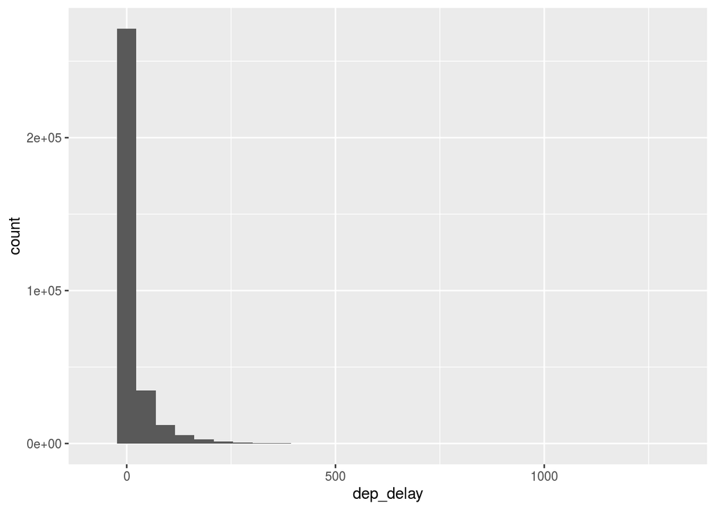

```r
flights %>%
  ggplot() +
  aes(x = dep_delay) +
  geom_histogram()
```

Alternativ:

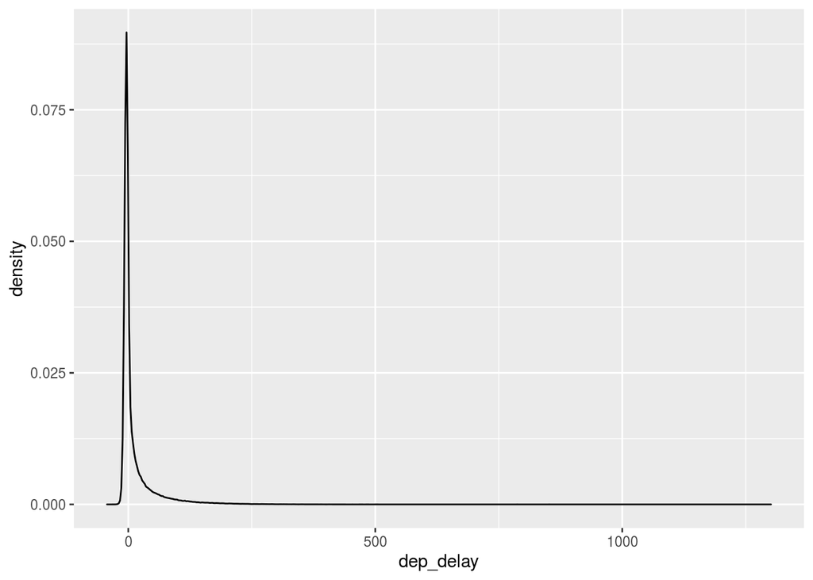

```r
flights %>%
  ggplot() +
  aes(x = dep_delay) +
  geom_density()
```

## 2. Visualisieren Sie die Verteilung der Verspätung der Flüge pro Abflugsort.

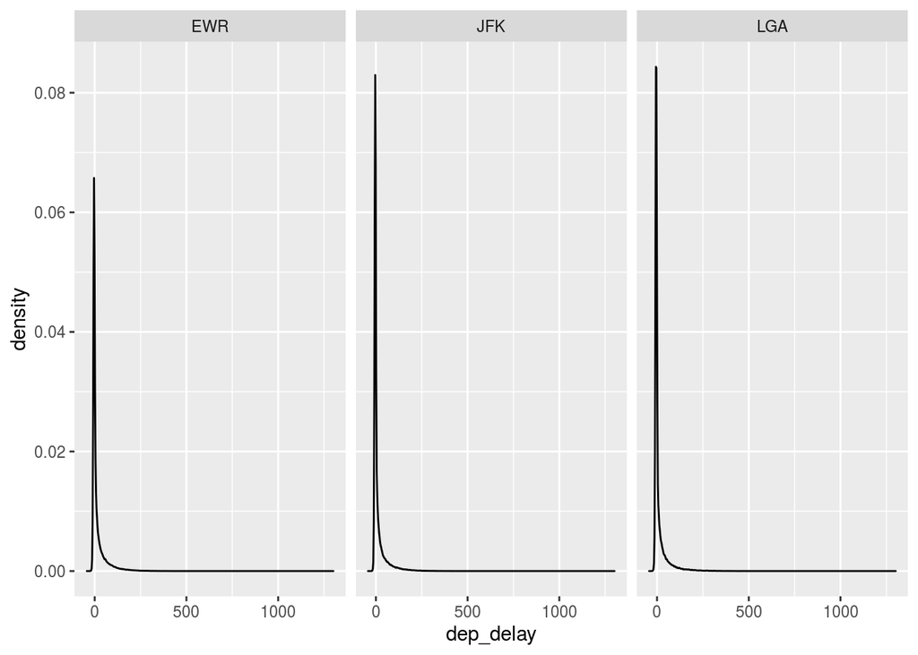

```r
flights %>%
  ggplot() +
  aes(x = dep_delay) +
  geom_density() +
  facet_wrap(~ origin)
```

## 3. Visualisieren Sie den Zusammenhang von Verspätung und Tageszeit. Reduzieren Sie dabei Overplotting.

*Tipp:* Anstelle von `geom_point()` mal `geom_bin2d()` ausprobieren.

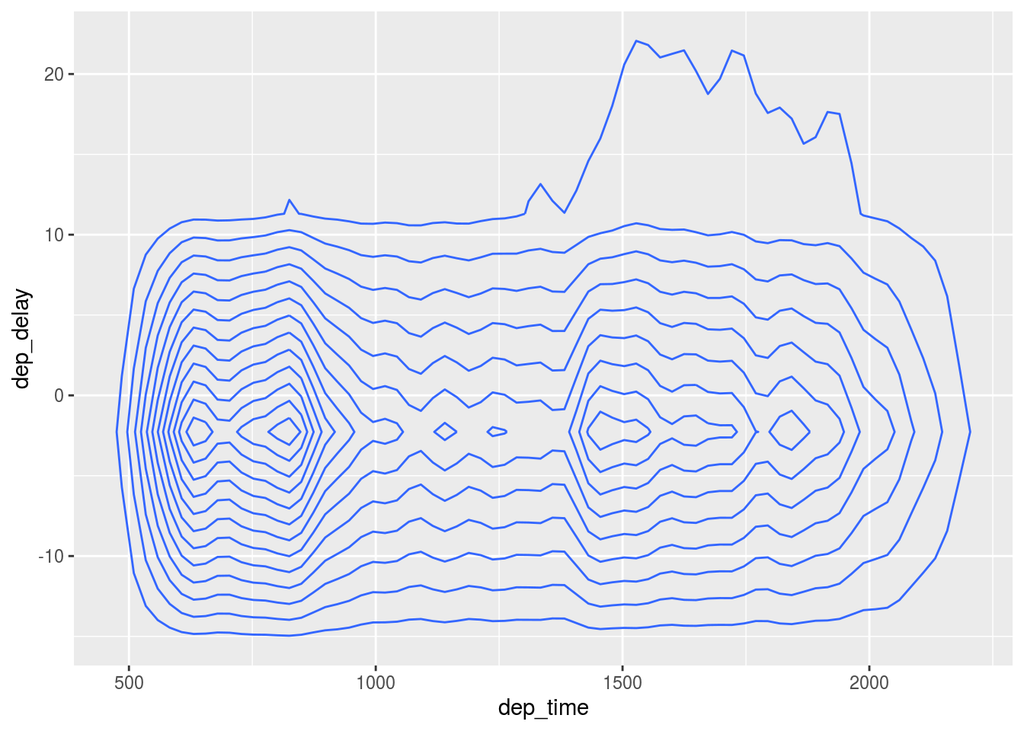

```r
flights %>%
  ggplot() +
  aes(x = dep_time, dep_delay) +
  geom_density2d()
```

## 4. Visualisieren Sie den Zusammenhang von Verspätung und Tageszeit – aufgeteilt nach Abflugsort und nach Stunde!

Reduzieren Sie dabei Overplotting.

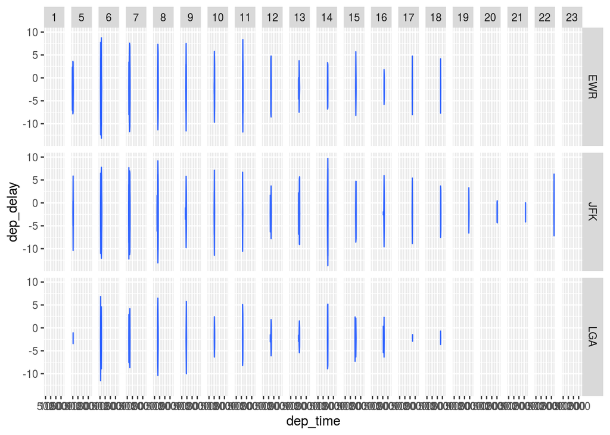

```r
flights %>%
  ggplot() +
  aes(x = dep_time, dep_delay) +
  geom_density2d() +
  facet_grid(origin ~ hour)
```

## 5. Visualisieren Sie den Zusammenhang von Verspätung und Tageszeit – für die drei Airlines mit der höchsten Durchschnittsverspätung.

Reduzieren Sie dabei Overplotting.

Airlines mit der höchsten Verspätung identifizieren:

```r
flights %>%
  group_by(carrier) %>%
  summarise(dep_delay_carrier = mean(dep_delay, na.rm = TRUE)) %>%
  arrange(-dep_delay_carrier) %>%
  slice(1:3)
```

```
## # A tibble: 3 x 2
##   carrier dep_delay_carrier
##   <chr>               <dbl>
## 1 F9                   20.2
## 2 EV                   20.0
## 3 YV                   19.0
```

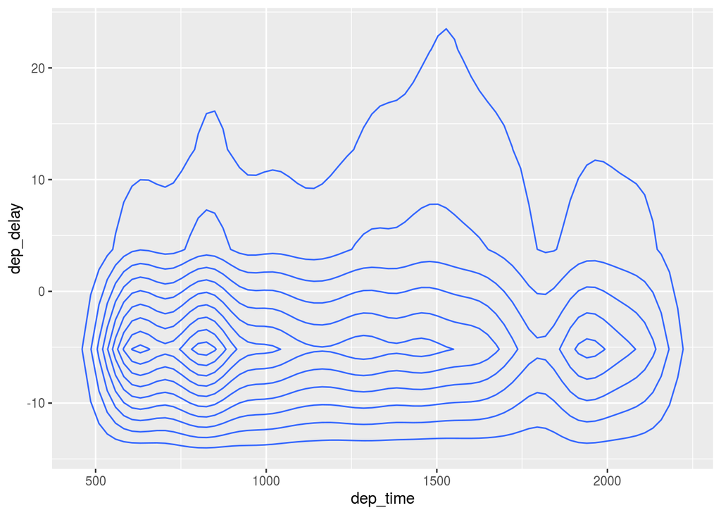

```r
flights %>%
  filter(carrier %in% c("F9", "EV", "YV")) %>%
  ggplot() +
  aes(x = dep_time, dep_delay) +
  geom_density2d()
```

## 6. Visualisieren Sie den Anteil der verspäteten Flüge nach Abflugsort.

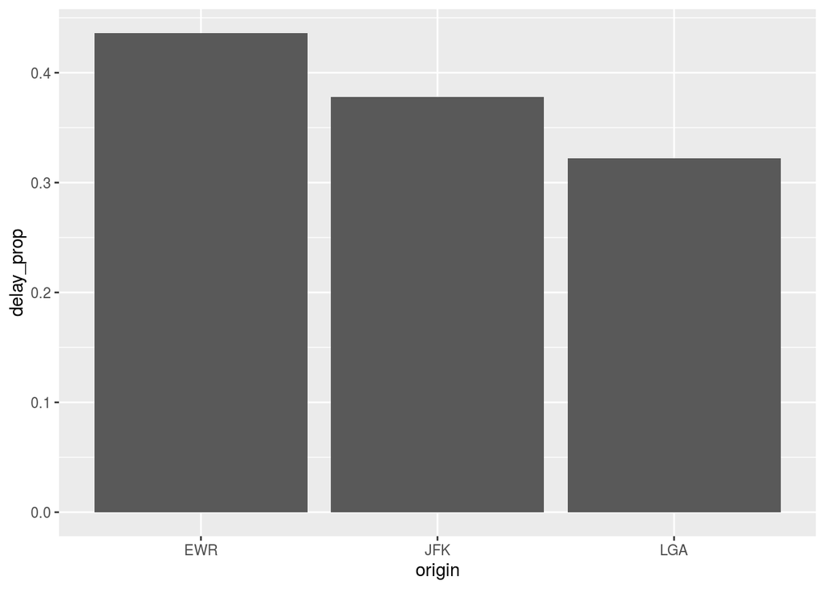

```r
flights %>%
  mutate(is_delayed = dep_delay > 0) %>%
  group_by(origin) %>%
  summarise(delay_n = sum(is_delayed == TRUE, na.rm = TRUE),
            delay_prop = delay_n / n()) %>%
  ggplot() +
  aes(x = origin, y = delay_prop) +
  geom_col()
```

Oder so:

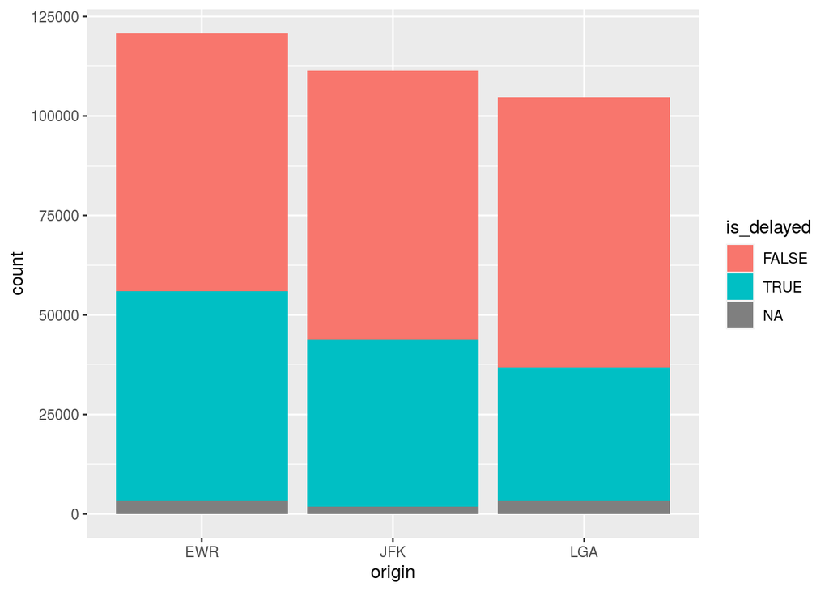

```r
flights %>%
  mutate(is_delayed = dep_delay > 0) %>%
  group_by(origin) %>%
  ggplot() +
  aes(x = origin, fill = is_delayed) +
  geom_bar()
```

Oder so:

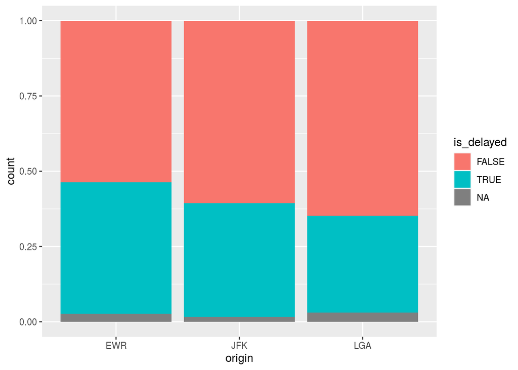

```r
flights %>%
  mutate(is_delayed = dep_delay > 0) %>%
  group_by(origin) %>%
  ggplot() +
  aes(x = origin, fill = is_delayed) +
  geom_bar(position = "fill")
```

## 7. Visualisieren Sie den Anteil der verspäteten Flüge nach Uhrzeit.

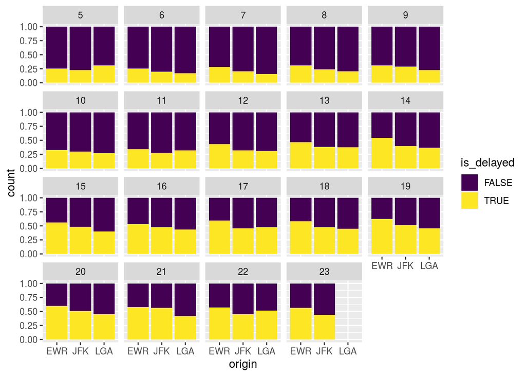

```r
flights %>%
  mutate(is_delayed = dep_delay > 0) %>%
  group_by(origin) %>%
  drop_na(is_delayed, origin) %>%
  ggplot() +
  aes(x = origin, fill = is_delayed) +
  geom_bar(position = "fill") +
  facet_wrap(~ hour) +
  scale_fill_viridis_d()  # d wie "discrete"
```

## 8. Visualisieren Sie den Anteil der verspäteten Flüge nach Monat.

Es gibt ein Paket, das einem die Arbeit mit Datum und Uhrzeit vereinfacht: `lubridate` (eigentlich gibt’s mehrere Pakete dieser Art).

```r
library(lubridate)
```

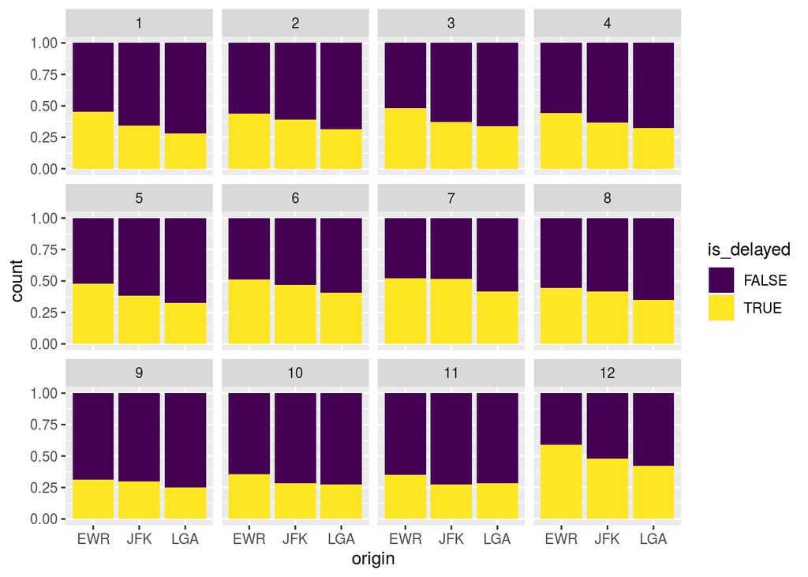

```r
flights %>%
  mutate(is_delayed = dep_delay > 0) %>%
  mutate(month = month(time_hour)) %>%
  group_by(origin) %>%
  drop_na(is_delayed, origin) %>%
  ggplot() +
  aes(x = origin, fill = is_delayed) +
  geom_bar(position = "fill") +
  facet_wrap(~ month) +
  scale_fill_viridis_d()  # d wie "discrete"
```